# MicroHub Workshop

A hands-on introduction to using MicroHub for infectious disease forecasting. The workshop helps participants install the software, prepare surveillance data, run and compare forecasting models, and export hub-ready probabilistic forecasts.

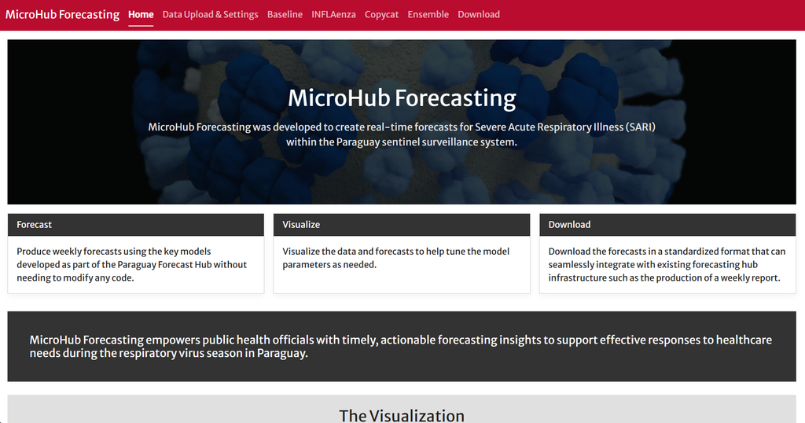

MicroHub application home page screenshot

## Workshop Purpose

MicroHub is designed to lower the technical barrier to producing transparent, reproducible infectious disease forecasts. These materials guide participants through a practical forecasting workflow: upload compatible surveillance data, choose real-time forecast settings, run several models, compare uncertainty, build an ensemble, and download outputs that can support collaborative forecasting hub workflows.

## What Participants Will Need

- Windows, macOS, or Linux laptop with administrator rights for software installation.
- Docker Desktop installed before the first hands-on session.
- Internet access for pulling the MicroHub container image and downloading workshop CSV files.
- Workshop datasets from the Downloads page.

## Learning Goals

- Run MicroHub locally using Docker Desktop.
- Prepare surveillance data with `date`, `target_group`, and `value` columns.
- Understand forecast date, data drop, seasonality, and horizon settings.
- Compare simple baselines with trajectory-matching and Bayesian models.
- Create ensemble forecasts and export hub-compatible outputs.

## Editing This Site

This repository is a small pkgdown site. Edit the source files, then rebuild the site:

```r
rmarkdown::render("README.Rmd")
pkgdown::build_site()
```

Common edits:

- Home page: `README.Rmd`
- Install guide: `vignettes/install.Rmd`
- Exercises: `vignettes/exercises.Rmd`
- Downloads page: `vignettes/downloads.Rmd`
- Troubleshooting: `vignettes/troubleshooting.Rmd`
- Contact page: `vignettes/contact.Rmd`
- Navigation and theme: `_pkgdown.yml`
- Downloadable CSVs: `pkgdown/assets/downloads/`